# Barplots Learning Checks

Albert Y. Kim

Mon Oct 11, 2016

## Load Packages and Data

```r
# Load necessary packages
library(ggplot2)
library(dplyr)
library(nycflights13)

data(flights)
data(airports)
```

## LC 4.27, 4.29, and 4.30

- Why are histograms inappropriate for visualizing categorical variables?
- How many Envoy Air flights departed NYC in 2013?
- What was the seventh highest airline in terms of departed flights from NYC in 2013?

### Solution

- Histograms are for continuous variables i.e. the horizontal part of each histogram bar represents an interval, whereas for a categorical variable each bar represents only one level of the categorical variable.
- Envoy Air is carrier code `MQ` and thus 26397 flights departed NYC in 2013. The `flights_table` and `airlines` datasets should be `join`ed so that this is easier to do.
- `US` i.e. US airways was 7th with 20536 flights. The `arrange(desc(n))` command came in real handy here!

## LC 4.31-4.32

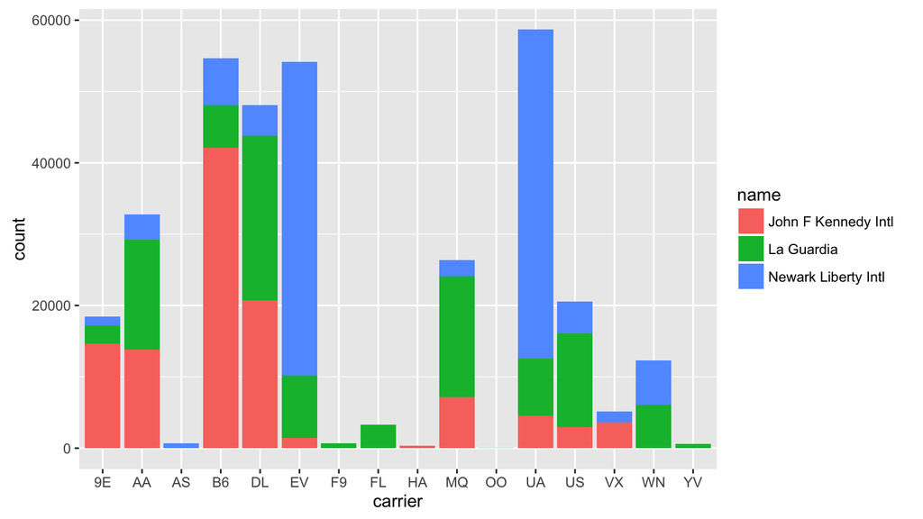

```r
flights_namedports <- inner_join(flights, airports, by = c("origin" = "faa"))
ggplot(data = flights_namedports, aes(x = carrier, fill = name)) +
  geom_bar()
```

- What kinds of questions are not easily answered by looking at the above figure?
- What can you say, if anything, about the relationship between airline and airport in NYC in 2013 in regards to the number of departing flights?

### Solution

- Because the red, green, and blue bars don’t all start at 0 (only red does), it makes comparing counts hard.
- The different airlines prefer different airports. For example, United is mostly a Newark carrier and JetBlue is a JFK carrier. If airlines didn’t prefer airports, each color would be roughly one third of each bar.

## LC 4.35-4.36

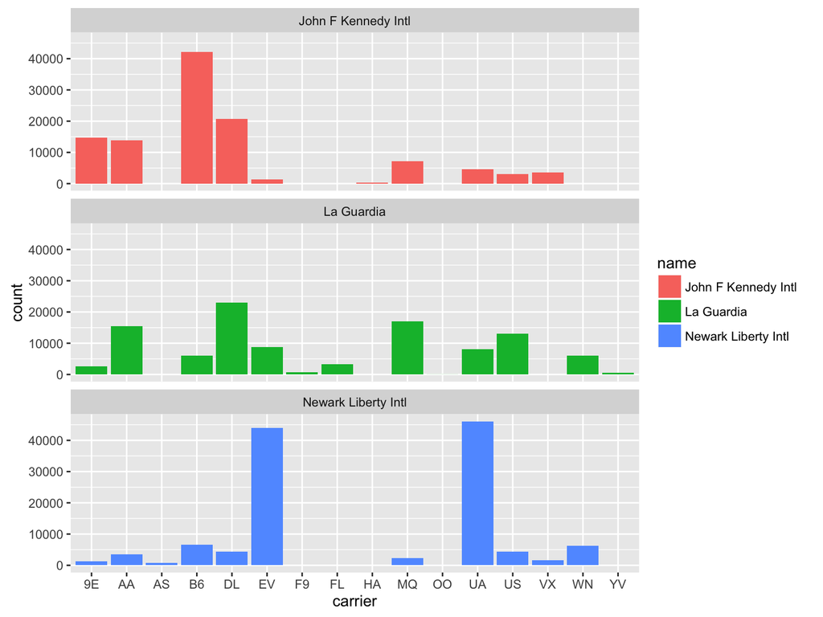

```r
ggplot(data = flights_namedports, aes(x = carrier, fill = name)) +
  geom_bar() +
  facet_wrap(~name, ncol=1)
```

- Why is the faceted barplot preferred to the stacked barplot in this case?
- What information about the different carriers at different airports is more easily seen in the faceted barplot?

### Solution

- We can easily compare the different aiports for a given carrier using a single vertical comparison line i.e. things are lined up
- Now we can also compare the different carriers **within** a particular airport easily too. For example, we can read off who the top carrier for each airport is easily using a single horizontal line.